# Lab 2

Becca Barrick

9/13/2020

##Searching for the Best Chocolates

1. How are the ratings distributed? Create both a histogram and a boxplot and describe them. Don’t forget to mention outliers, if there are any.

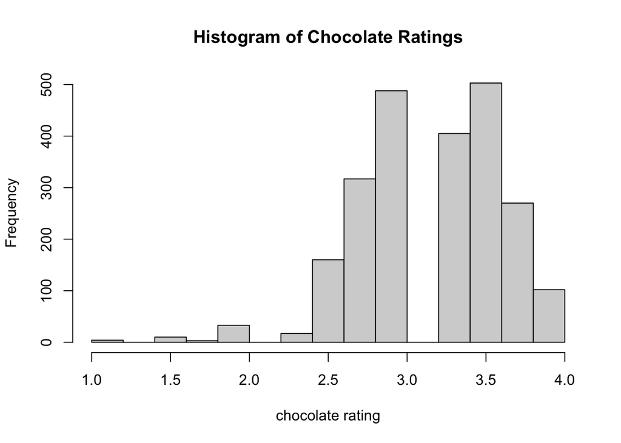

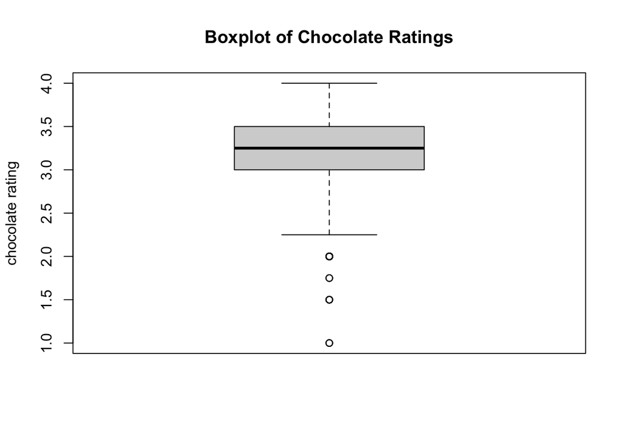

The histogram shows that the ratings are skewed left. Most ratings lie between 2.75 and 3.75. Very few chocolate bars have a rating below 2.5. The boxplot shows some obvious “outliers” between ratings of 1 and 2. They seem like outliers but are still in the range of normal rating.

2. How does the number of ratings depend on the year? Draw a bar chart of the number of reports.

```
## years
## 2006 2007 2008 2009 2010 2011 2012 2013 2014 2015 2016 2017 2018 2019 2020
##   62   73   92  123  110  163  194  184  247  284  219  105  228  195   33
```

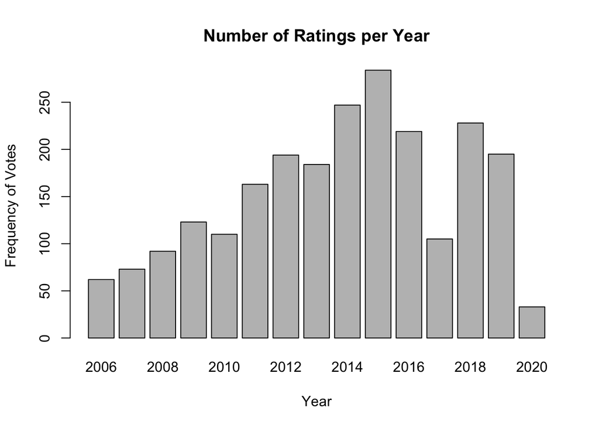

This barplot shows that the number of ratings had an overall steady increase from 2006 to 2015. There was then some random drops in amount of ratings in 2017 and 2020. 2020 has the lowest amount of ratings, most likely because the year is only 3/4 over.

3. Do ratings depend on the cacao percentage of a chocolate bar? Create both numerical and graphical summaries, and explain.

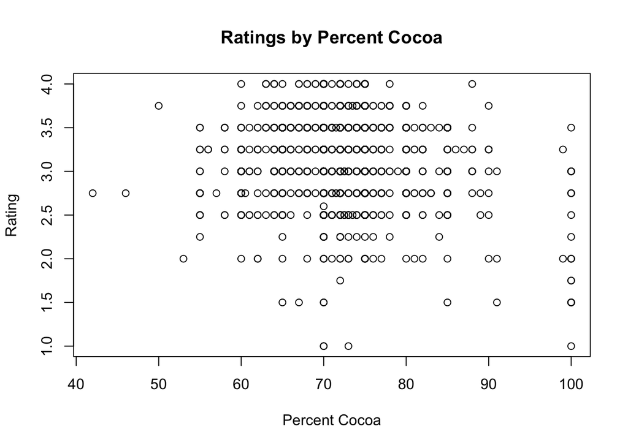

4. How do different characteristics of the chocolate compare? To elaborate, which characteristics tend to be more favorable and which ones are not? Create both numerical and graphical summaries, and explain.

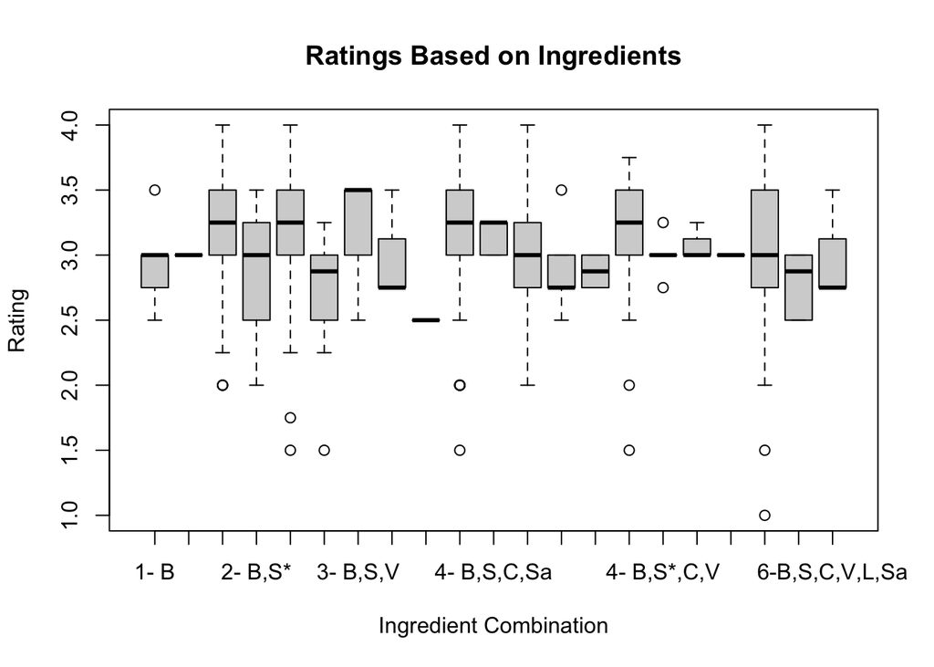

This analysis takes a lot at the ratings of chocolate based on ingredients. We can see in the plot that there are a few different ingredient combinations that lead to lower or higher ratings. For example, the combination of BS, meaning beans and sugar, has an average rating of about 3.25. The combination of beans, salt, and alternative sweetener, on the other hand, has an average rating of about 2.5.

5. Brainstorm two analyses you would like to perform with your teammate. Describe in plain language what comparisons are you making. Create suitable numerical and graphical summaries for your analyses. Describe the results.